# Comparison of clonal profiles

## Load data

We load the scRNA data of HNSCC26 Primary and HNSCC26 Lymph Node sample from the public dataset of Head&Neck cancer (GSE10332)

```r
load(url("https://github.com/AntonioDeFalco/SCEVAN/raw/main/data/HNSCC26_data.RData"))
```

## Run comparison

We run the pipeline that performs the classification of malignant and non-malignant cells in the two samples (Primary and Lymph Node) and compares the clonal profile of cancer cells inferred from the two samples, using 20 cores.

```r
library(SCEVAN)

results <- compareClonalStructure(count_mtx1 = count_mtx_prim, count_mtx2 = count_mtx_lymph, samp_1 = "HNSCC26_prim", samp_2 = "HNSCC26_lymph", par_cores = 20)
```

```
## [1] "HNSCC26_prim"
## [1] " raw data - genes: 23686 cells: 130"
## [1] "1) Filter: cells > 200 genes"
## [1] "2) Filter: genes > 10% of cells"
## [1] "10262 genes past filtering"
## [1] "found 2 confident non malignant cells"
## [1] "3) Annotations gene coordinates"
## [1] "9266 genes annotated"
## [1] "4) Filter: genes involved in the cell cycle"
## [1] "8774 genes past filtering "
## [1] "5)  Filter: cells > 5genes per chromosome "
## [1] "6) Log Freeman Turkey transformation"
## [1] "A total of 130 cells, 8774 genes after preprocessing"
## [1] "8): measuring baselines (confident normal cells)"
## [1] "7) Smoothing data"
## [1] "9) Segmentation (VegaMC)"
## [1] "10) Adjust baseline"
## [1] "11) plot heatmap"
```

```
## [1] "found 58 tumor cells"
## [1] "HNSCC26_lymph"
## [1] " raw data - genes: 23686 cells: 298"
## [1] "1) Filter: cells > 200 genes"
## [1] "2) Filter: genes > 10% of cells"
## [1] "12199 genes past filtering"
## [1] "found 3 confident non malignant cells"
## [1] "3) Annotations gene coordinates"
## [1] "10954 genes annotated"
## [1] "4) Filter: genes involved in the cell cycle"
## [1] "10429 genes past filtering "
## [1] "5)  Filter: cells > 5genes per chromosome "
## [1] "6) Log Freeman Turkey transformation"
## [1] "A total of 298 cells, 10429 genes after preprocessing"
## [1] "8): measuring baselines (confident normal cells)"
## [1] "7) Smoothing data"
## [1] "9) Segmentation (VegaMC)"
## [1] "10) Adjust baseline"
## [1] "11) plot heatmap"
```

```
## [1] "found 213 tumor cells"
```

```
## [1] "HNSCC26_prim-vs-HNSCC26_lymph"
```

## Output

The pipeline returns in *results* a data frame containing for each cell its classification (tumor/normal), whether it has been used as a normal confident cell.

```r
head(results)
```

```
##                       class confidentNormal
## HN26_P6_B06_S18_comb normal            <NA>
## HN26_P5_H01_S85_comb  tumor            <NA>
## HN26_P5_E06_S54_comb  tumor            <NA>
## HN26_P6_D08_S44_comb  tumor            <NA>
## HN26_P5_D12_S48_comb normal            <NA>
## HN26_P5_G11_S83_comb normal            <NA>
```

And creates an output folder containing segmentation output files and all the plots generated by the analysis:

```r
list.files(path = "./output", pattern = "HNSCC26")
```

```
##  [1] " HNSCC26_lymph vega_output"                  " HNSCC26_lymphonlytumor vega_output"
##  [3] " HNSCC26_prim vega_output"                   " HNSCC26_primonlytumor vega_output"
##  [5] "HNSCC26_lymph_mtx_vega.txt"                  "HNSCC26_lymphheatmap.png"
##  [7] "HNSCC26_lymphonlytumor_mtx_vega.txt"         "HNSCC26_lymphonlytumorheatmap.png"
##  [9] "HNSCC26_prim_mtx_vega.txt"                   "HNSCC26_prim-vs-HNSCC26_lymphconsensus.png"
## [11] "HNSCC26_prim-vs-HNSCC26_lymphOncoHeat.png"   "HNSCC26_prim-vs-HNSCC26_lymphplotCNline.png"
## [13] "HNSCC26_primheatmap.png"                     "HNSCC26_primonlytumor_mtx_vega.txt"
## [15] "HNSCC26_primonlytumorheatmap.png"
```

### Heatmap classification of tumor cells (heatmap.png)

Heatmap of the Copy Number Alteration matrix with classification of non-malignant and malignant cells.

Primary

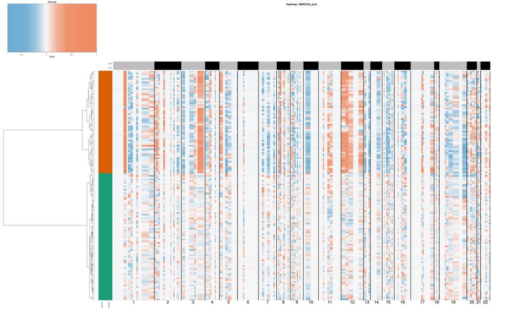

Lymph node

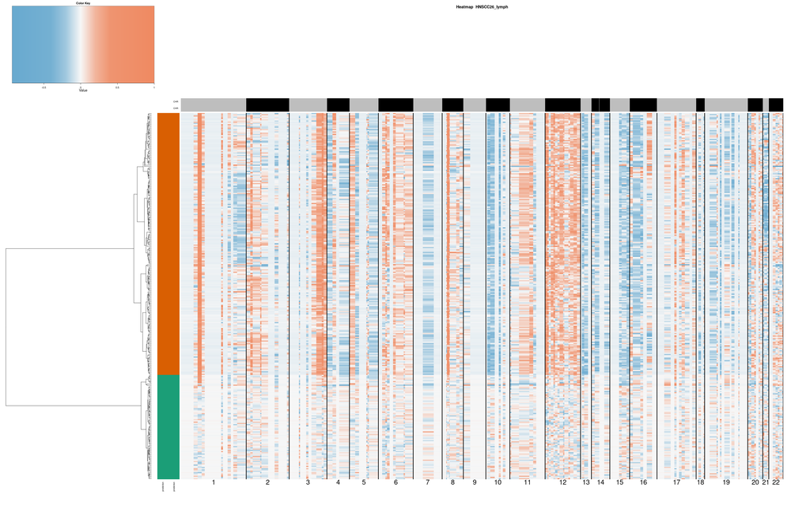

### Consensus plot (consensus.png)

Compact plot of the alterations present in each sample.

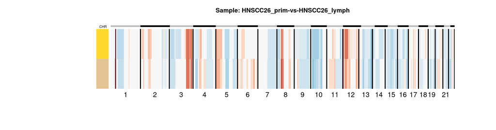

### Copy number plot (CNline.png)

Copy number plot that highlighting specific alteration, shared alteration between samples.

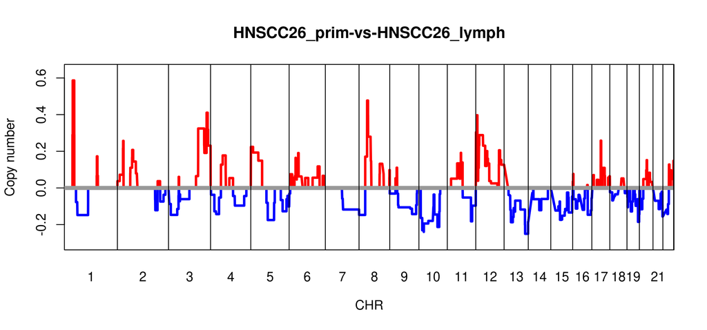

### OncoPrint-like plot (OncoHeat.png)

OncoPrint-like plot that highlighting specific alteration, shared alteration between samples.

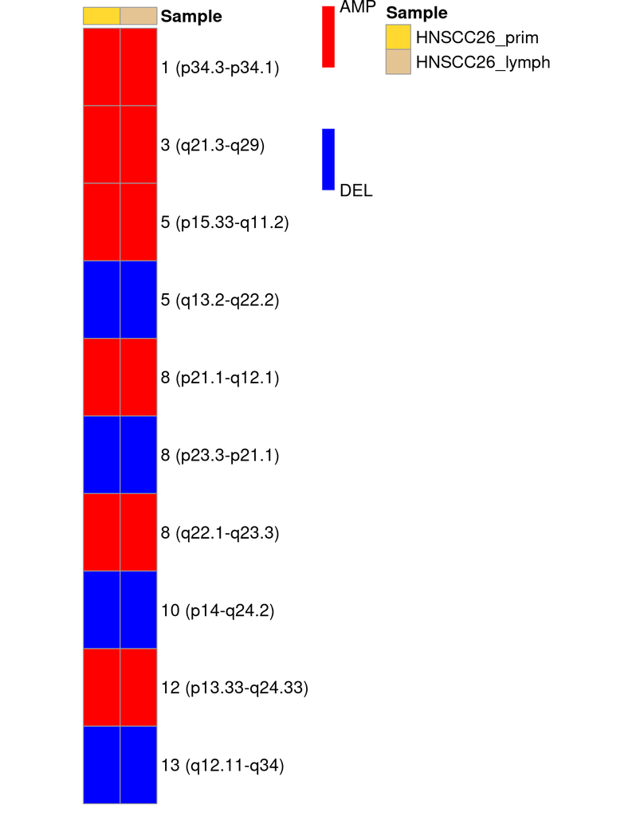